# STAT482-Time series

Huiyan Sang

# Time Series

- A time series is simply a series of data points ordered in time.
- The goal is to study the temporal pattern and/or make a forecast for the future.
- Examples:
  - Stock price
  - Electricity consumption
  - Daily temperature

# Time series

- Is the times series autocorrelated?
- Is it stationary?
- Is there a seasonality?

# R packages

- xts
- zoo
- forecast
- quantmod
- tidyquant

# Summary with time series object

```r
library(forecast)
```

```r
library(ggplot2)
head(gas)
```

```
##       Jan  Feb  Mar  Apr  May  Jun
## 1956 1709 1646 1794 1878 2173 2321
```

```r
start(gas)
```

```
## [1] 1956    1
```

```r
end(gas)
```

```
## [1] 1995    8
```

```r
frequency(gas)
```

```
## [1] 12
```

# Plot with time series object

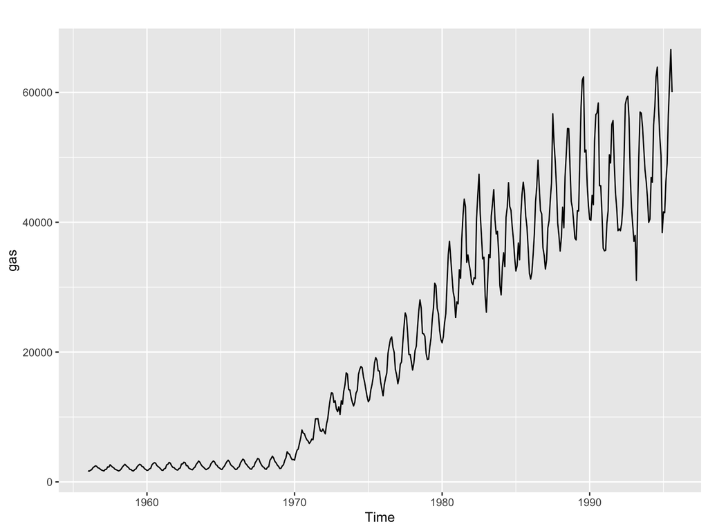

```r
autoplot(gas) ## this is a time series object
```

```r
tseries_sub <- window(gas, start=c(1990, 1), end=c(1994,12))
print(tseries_sub)
```

```
##        Jan   Feb   Mar   Apr   May   Jun   Jul   Aug   Sep   Oct   Nov   Dec
## 1990 40459 40295 44147 42697 52561 56572 56858 58363 45627 45622 41304 36016
## 1991 35592 35677 39864 41761 50380 49129 55066 55671 49058 44503 42145 38698
## 1992 38963 38690 39792 42545 50145 58164 59035 59408 55988 47321 42269 39606
## 1993 37059 37963 31043 41712 50366 56977 56807 54634 51367 48073 46251 43736
## 1994 39975 40478 46895 46147 55011 57799 62450 63896 57784 53231 50354 38410
```

```r
is.ts(gas)
```

```
## [1] TRUE
```

# Convert your data to a time series object

```r
head(economics,2)
```

```
## # A tibble: 2 x 6
##   date         pce    pop psavert uempmed unemploy
##   <date>     <dbl>  <dbl>   <dbl>   <dbl>    <dbl>
## 1 1967-07-01  507. 198712    12.6     4.5     2944
## 2 1967-08-01  510. 198911    12.6     4.7     2945
```

```r
tail(economics ,2)
```

```
## # A tibble: 2 x 6
##   date          pce     pop psavert uempmed unemploy
##   <date>      <dbl>   <dbl>   <dbl>   <dbl>    <dbl>
## 1 2015-03-01 12158. 320231.     7.4    12       8504
## 2 2015-04-01 12194. 320402.     7.6    11.5     8526
```

# Convert your data to a time series object and plot it

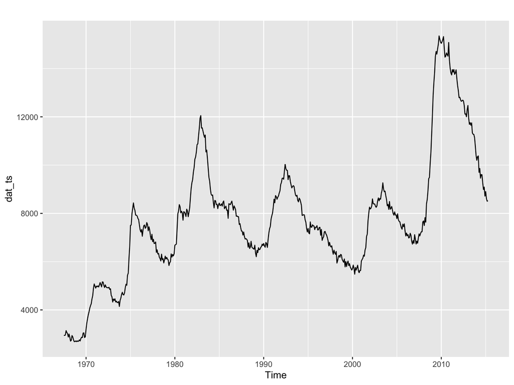

```r
dat_ts <- ts(economics$unemploy, start = c(1967, 7), end = c(2015, 4), frequency = 12)
autoplot(dat_ts)
```

# Convert your data to a multivariate time series object and plot it

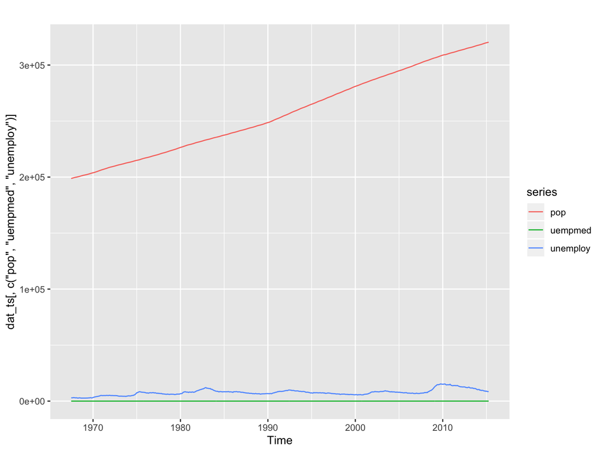

```r
dat_ts <- ts(economics[,2:6], start = c(1967, 7), end = c(2015, 4), frequency = 12)
autoplot(dat_ts[,c('pop','uempmed','unemploy')]) ## plot multiple time series
```

# Autocorrelations

- Autocorrelation, also called serial correlation, is the correlation of a signal with a delayed copy of itself as a function of delay.
- It measures the similarity between observations as a function of the time lag between them.
  - Lag-1 autocorrelation, $\rho(1)=\text{corr}(x_t,x_{t-1})$
  - Lag-2 autocorrelation, $\rho(2)=\text{corr}(x_t,x_{t-2})$
  - $\rho(k)$ is called the autocorrelation function that shows lag-k correlations

# Autocorrelations

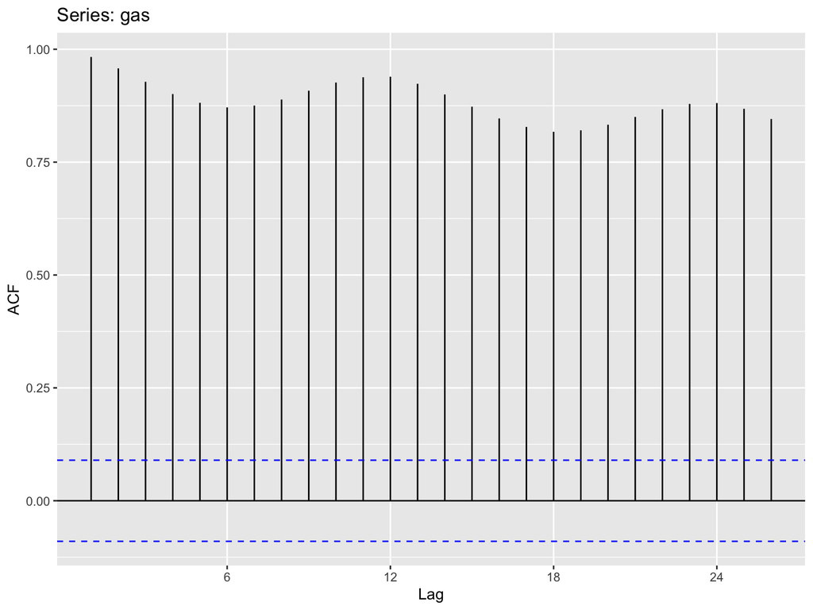

```r
ggAcf(gas)
```

# More on autocorrelations

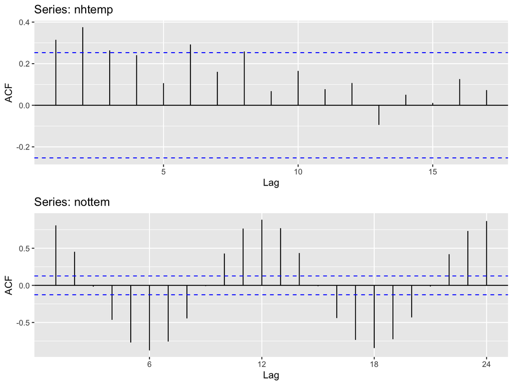

```r
g1=ggAcf(nhtemp) ## Annual temperatures in New Haven
g2=ggAcf(nottem) ## Monthly temperatures at Nottingham
gridExtra::grid.arrange(g1,g2,nrow=2)
```

# Seasonality

Additive decompositions Time series = Seasonal + Trend + Random

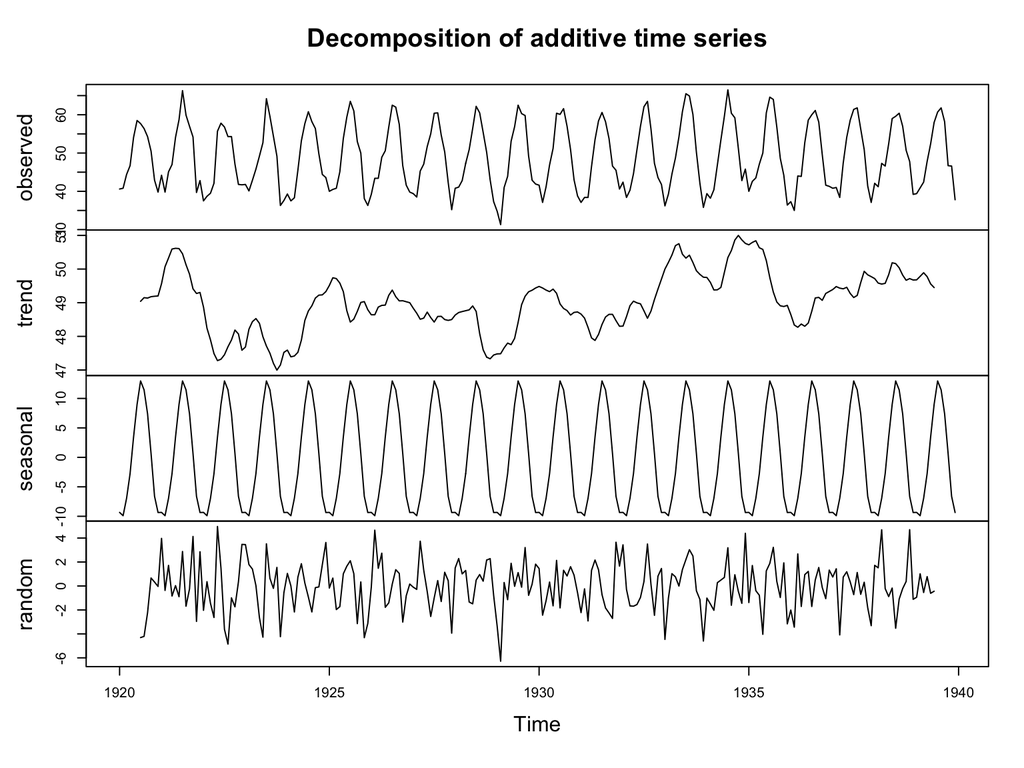

```r
decom.ts=decompose(nottem)
plot(decom.ts)
```

# Fit an autoregressive integrated moving averages model.

auto.arima() automatically determines orders and check for seasonality etc.

```r
fit <- auto.arima(gas)
#accuracy(fit)
```

# Forecasting usingthe fitted arima model

```r
forecast(fit, 1)
```

```
##          Point Forecast    Lo 80    Hi 80    Lo 95    Hi 95
## Sep 1995       56907.83 54846.53 58969.13 53755.35 60060.32
```

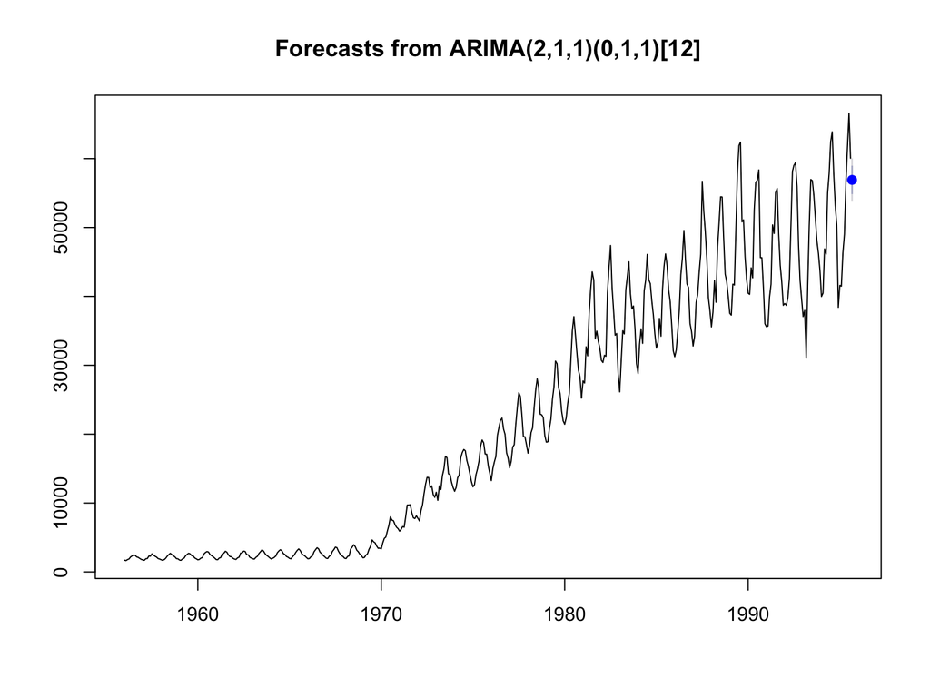

```r
plot(forecast(fit, 1))
```

# Stationarity vs Nonstationarity

- Definition If $\{y_t\}$ is a stationary time series, then for all $s$, the distribution of $(y_t,\ldots, y_{t+s})$ does not depend on $t$.
- Its statistical properties (mean, variance and covariance among time series) do not change over time.
- How to check stationarity?
- How to convert nonstationary TS to stationary TS?

# Stationarity vs Nonstationarity

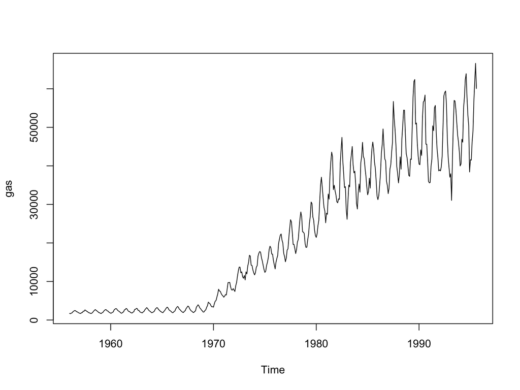

```r
library(tseries)
plot(gas)
```

# Augmented Dickey-Fuller test

```r
adf.test(gas)
```

```
##
##  Augmented Dickey-Fuller Test
##
## data:  gas
## Dickey-Fuller = -2.7131, Lag order = 7, p-value = 0.2764
## alternative hypothesis: stationary
```

# Take differences to make the time series stationary

```r
adf.test(diff(gas))
```

```
##
##  Augmented Dickey-Fuller Test
##
## data:  diff(gas)
## Dickey-Fuller = -19.321, Lag order = 7, p-value = 0.01
## alternative hypothesis: stationary
```

# Relationship between two time series

Cross-correlation function (CCF) is defined analogously to the ACF. It measures the lagged correlation between two time series. $\rho(k)=\text{corr}(x_t,y_{t-k})$

```r
dat_ts <- ts(economics[,c('pop','unemploy')],
             start = c(1967, 7), end = c(2015, 4),
             frequency = 12)
pop <- diff (dat_ts[,1])
unemploy <- diff(dat_ts[,2])
```

# CCF plot

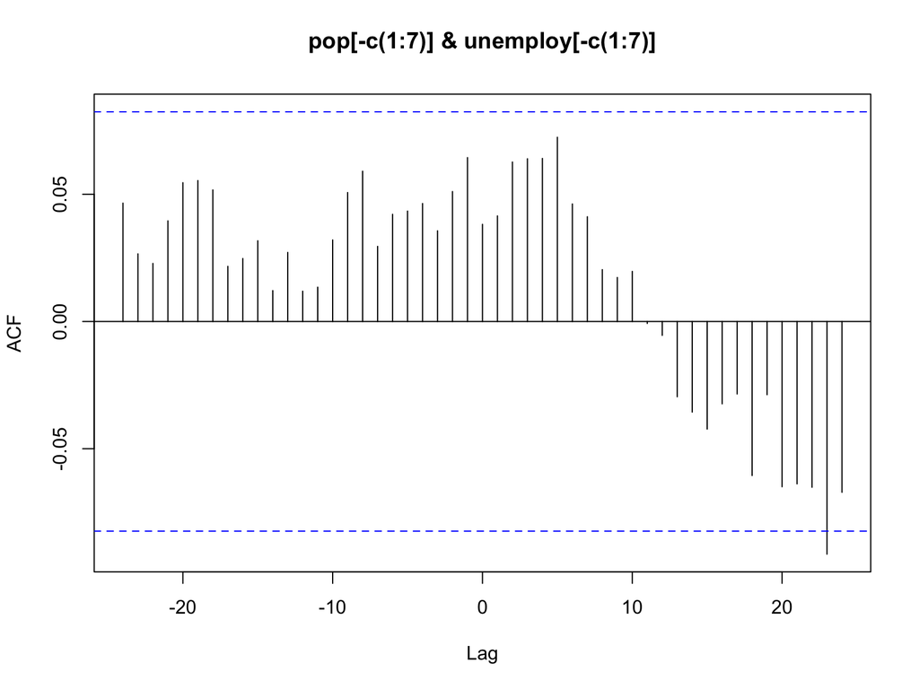

```r
ccf (pop[-c(1:7)], unemploy[-c(1:7)])
```